# MatthewSmith_Final

## 8.

What’s the big picture, based on all of the foregoing analyses? The staff member in the state legislator’s office is interested to know how to allocate financial assistance to school districts to improve both their vaccination rates and their reporting compliance. What have you learned from the data and analyses that might inform this question?

## Techincal Report.

Below is my technical analysis based on questions submitted and data related to allocating financial assistance to schools in order to improve vaccination rates and reporting:

### Analysis of available data.

First, we took a look at the overall vaccination rates in the United States for the selected vaccinations over the past thirty years, just to get a feel for the trend. See Figure 1.

[figure not shown]

From Figure 1, we can see that there has been significant improvement across the U.S. in terms of vaccination rates for these specific vaccinations. However, we are more concerned at this time with the rates in the school districts of California. To start on this analysis, we need to differentiate between the public and private schools. See Figure 2.

[figure not shown]

From Figures 2.1 and 2.2 above, we can see that public schools have a significantly higher reporting rate (~97.4%) than private schools (~84.7%) in California. Also, California as a whole appears to be lacking in the vaccination rates in DTP and Polio (see Figure 3.). There was a significant difference found in the mean reporting rates between public and private schools (t = 13.944, p < 0.001) (see Figure 4.)

[figure not shown]

**Figure 4 - Results of t-test: Differences between public and private school vaccination reporting.**

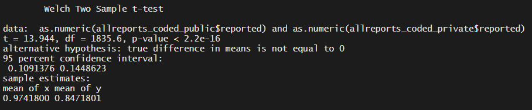

In the case of reporting, we may want to allocated funds to reaching out to the private schools to see why they are lacking in reporting compared to their public counter parts. For the rest of this report, we will be focusing on all districts and the factors that may lead to lower reporting and vaccination rates.

The first specific question that we talked with this analysis is which factors predict whether or not a district’s reporting was complete (regardless of public/private status). We looked at the following variables as predictors of a district completing its reporting, starting with a binomial regression (generalized linear model). See Figure 5:

- `PctChildPoverty` : Percentage of children in the district living below the poverty line
- `PctFreeMeal` : Percentage of children in the district eligible for free student meals
- `PctFamilyPoverty` : Percentage of families in the district living below the poverty line
- `Enrolled` : Total number of enrolled students in the district
- `TotalSchools` : Total number of different schools in the district

**Figure 5 - Results of generalized linear model regression (binomial): predictors of district vaccination reporting completion**

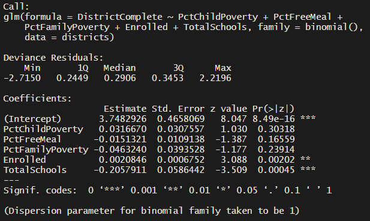

An analysis using A Bayesian logit model was also performed in order to get a sense of the predicted population (see Figure 6).

**Figure 6 - Plots of Bayesian logit model (binomial): predictors of district vaccination reporting completion**

[figure not shown]

From Figures 5 and 6 above, we can see that only the variables of `Enrolled` (t = 3.088, p < 0.01) and `TotalSchools` (t = -3.509, p < 0.001) were possible viable predictors of vaccination report completion for the sample and predicted population. However, when a test for multicollinearity was performed, these variables each reported a score of ~ 48 (much higher than the 1-5 range for them to be considered a viable predictor). See Figure 7.

**Figure 7 - Results of multicollinearity test (`vif()`) for predictors of district vaccination report completion**

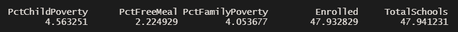

The second specific question we pursued was which factors predicted the percentage of all enrolled students with completely up-to-date vaccine. We used the same approach as the previous question, starting with a general liner model and then confirming with a Bayesian analysis. We looked at the same variables as predictors from the previous question (See Figure 8.1):

**Figure 8.1 - Results of generalized linear model for predictors of percentage of students with completely up-to-date vaccine**

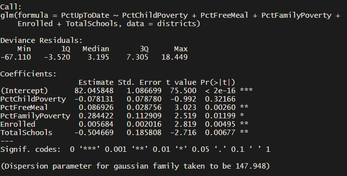

Here, we can see what all variables included in this regression analysis (except for `PctChildPoverty`), appear to be viable cadidates for prediction of students being up-to-date on all vaccines. To confirm this, we turn to the Bayesian analysis (see Figure 8.2)

**Figure 8.2 - Results of Bayesian analysis for predictors of percentage of students with completely up-to-date vaccine**

[figure not shown]

In the Bayesian analysis, we see that all of the histograms of the frequencies of percentages (minus `PctChildPoverty`) do not include zero in the 95% HDI; this indicates that those variables would be good candidates for predicting up-to-date vaccination rates. However, we again turn to the multicollinearity test to check how viable these predictors are (See figure 9):

**Figure 9 - Results of multicollinearity test for predictors of percentage of students with completely up-to-date vaccine**

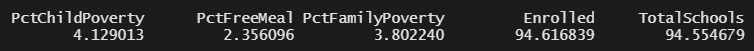

Again, we see that the `Enrolled` and `TotalSchools` variables fail the multicollinearity test, leaving `PctFreeMeal` and `PctFamilyPoverty` as the last-standing viable predictors of students being completely up-to-date on their vaccines.

### Recommendations.

Also, even though the variables concerning the total number of students enrolled in a district and the number of schools in a district failed collinearity tests and may not be statistically significant, it may be worth investigating if districts are having issues with keeping up with sheer numbers of students.